# Statistical inference with the GSS data

## Setup

### Load packages

```r
library(ggplot2)
library('latex2exp')
library(dplyr)     #pipe line processing
library(knitr)     #kable function call
library(reshape2)  #dcast function call
library(DiagrammeR)#grpviz
library(statsr)
```

### Load data

```r
load("gss.Rdata")
```

### Report Counters

This section initializes counters used in this report.

```r
id_label = 0   #Used to label kable table outputs.
```

## Part 1: Data

Since 1972, the General Social Survey (GSS) has been monitoring societal change and studying the growing complexity of American society. The GSS aims to gather data on contemporary American society in order to monitor and explain trends and constants in attitudes, behaviors, and attributes; to examine the structure and functioning of society in general as well as the role played by relevant subgroups; to compare the United States to other societies in order to place American society in comparative perspective and develop cross-national models of human society; and to make high-quality data easily accessible to scholars, students, policy makers, and others, with minimal cost and waiting.

GSS questions cover a diverse range of issues including national spending priorities, marijuana use, crime and punishment, race relations, quality of life, confidence in institutions, and sexual behavior.

Source: [Duke University Data and Visualization Services](http://guides.library.duke.edu/c.php?g=289704&p=1930833)

### Methodology [methodology](https://en.wikipedia.org/wiki/General_Social_Survey#Methodology)

The target population of the GSS is adults (18+) living in households in the United States. The GSS sample is drawn using an area probability design that randomly selects respondents in households across the United States to take part in the survey. Respondents that become part of the GSS sample are from a mix of urban, suburban, and rural geographic areas. Participation in the study is strictly voluntary. However, because only about a few thousand respondents are interviewed in the main study, every respondent selected is very important to the results.

The survey is conducted face-to-face with an in-person interview by NORC at the University of Chicago. The survey was conducted every year from 1972 to 1994 (except in 1979, 1981, and 1992). Since 1994, it has been conducted every other year. The survey takes about 90 minutes to administer. As of 2014, 30 national samples with 59,599 respondents and 5,900+ variables have been collected.

Source: [Wiki](https://en.wikipedia.org/wiki/General_Social_Survey#Methodology) * * *

## Part 2: Research question

The survey posed `RACE OF RESPONDENT` and `SHOULD GOVT AID BLACKS?`question. Here are the actual questions and possible responces.

| Section | SubSection | Col# | Column Name | Description |
| --- | --- | --- | --- | --- |
| Respondent Background Variables |  | 5 | race | Race of respondent |
| Obligations and Responsibilities | Government Responsibility | 114 | helpblk | Should govt aid blacks? |

| ID | ID Description | Survey Question |
| --- | --- | --- |
| RACE | RACE OF RESPONDENT | What race do you consider yourself? |

| VALUE | LABEL |
| --- | --- |
| NA | IAP |
| 1 | WHITE |
| 2 | BLACK |
| 3 | OTHER |

| ID | ID Description | Survey Question |
| --- | --- | --- |
| HELPBLK | SHOULD GOVT AID BLACKS? | Now look at card BF. Some people think that (blacks/negroes/African-Americans) have been discriminated against for so long that the government has a special obligation to help improve their living sta… |

| VALUE | LABEL |
| --- | --- |
| NA | IAP |
| 1 | GOVT HELP BLKS |
| 3 | AGREE WITH BOTH |
| 5 | NO SPECIAL TREATMENT |
| NA | DK |
| NA | NA |

Today’s society seems to be splintering into different race, gender, social economic, and religious factions. This cannot be good thing for a country that draws it strength from its diversity, the melting pot of people. With the election of America’s first black President, and the $50^{th}$ anniversary of the assination of Martin Luther King, the Black Lives Matter movement, and racial tensions in general, how do blacks and whites see the role of their government in helping blacks? Different variations of this question appear in one form or another of affirmative action and reverse discrimination.

What is the relationship between races and their views on the role of government helping blacks?

## Part 3: Exploratory data analysis

This section prepares the `gss` sample data for analysis in a series of steps. The different sections are sequenced with an id label. The id label consists of a Part Number and a Step Number separated by a period, e.g., id label 3.1 represents Part 3: Exploratory data analysis, step 1. If there is an associated code block with a `kable` table, the `caption` setting will include the id label.

### 3.1 Review the `gss` dataset race and helpblk variables

This codeblock summarizes the race and helpblk variable responces. The summarized values are the counts, cumulative counts and percentages within each race group.

```r
id_label = id_label+1
xrh <- gss %>% group_by(race,helpblk) %>% summarize(help_cnt=n())
xr  <- xrh %>% group_by(race) %>% summarize(race_cnt=sum(help_cnt))
xrh_j <- xrh %>% inner_join(xr,by='race') %>%
    mutate( help_pct=100*help_cnt/race_cnt
           ,race_cumsum=cumsum(help_cnt)
           ,race_cumpct=cumsum(help_pct)
           ) %>%
    select(race,helpblk,help_cnt,help_pct,race_cumsum,race_cumpct)
kable(xrh_j,caption=paste0('Step 3.',id_label,': Summarized race and helpblk variable responces'))
```

Step 3.1: Summarized race and helpblk variable responces

| race | helpblk | help_cnt | help_pct | race_cumsum | race_cumpct |
| --- | --- | --- | --- | --- | --- |
| White | Govt Help Blks | 1159 | 2.500539 | 1159 | 2.500539 |
| White | Agree With Both | 6614 | 14.269687 | 7773 | 16.770226 |
| White | No Special Treatment | 7953 | 17.158576 | 15726 | 33.928803 |
| White | NA | 30624 | 66.071197 | 46350 | 100.000000 |
| Black | Govt Help Blks | 1345 | 16.969468 | 1345 | 16.969468 |
| Black | Agree With Both | 1357 | 17.120868 | 2702 | 34.090336 |
| Black | No Special Treatment | 332 | 4.188746 | 3034 | 38.279081 |
| Black | NA | 4892 | 61.720919 | 7926 | 100.000000 |
| Other | Govt Help Blks | 184 | 6.606822 | 184 | 6.606822 |
| Other | Agree With Both | 569 | 20.430880 | 753 | 27.037702 |
| Other | No Special Treatment | 371 | 13.321364 | 1124 | 40.359066 |
| Other | NA | 1661 | 59.640934 | 2785 | 100.000000 |

It seems odd that the dataset only has three races, White, Black, and Other.

### 3.2 Filter out the NA data from the dataset

From the table above we see that about 60% of the `gss` dataset has an `NA` for the `helpblk` variable. The next section filters these rows out of the future analysis.

```r
#ID: 3.2
id_label = id_label+1
x1<-gss %>% filter(!is.na(helpblk))%>% group_by(race,helpblk) %>% summarize(n=n())
kable(x1,caption=paste0('Step 3.',id_label,': Filter Data for non NA Race and Helping Black Responses'))
```

Step 3.2: Filter Data for non NA Race and Helping Black Responses

| race | helpblk | n |
| --- | --- | --- |
| White | Govt Help Blks | 1159 |
| White | Agree With Both | 6614 |
| White | No Special Treatment | 7953 |
| Black | Govt Help Blks | 1345 |
| Black | Agree With Both | 1357 |
| Black | No Special Treatment | 332 |
| Other | Govt Help Blks | 184 |
| Other | Agree With Both | 569 |
| Other | No Special Treatment | 371 |

### 3.3 Create a two-way table or a contingency table

Since we are analyzing categorical data with multiple variable, we will perform a row to column pivot on the data to help show the relationships between different races and the different government help responses. This will be the observed data, `obs_values.` The contingency table is used to calculate the expected observed values necessary to performa a $\chi^2$ test on categorical data with more than one variable.

```r
#ID: 3.3
id_label = id_label+1
obs_values <-dcast(x1,race ~ helpblk,value.var = 'n')
kable(obs_values,caption=paste0('Step 3.',id_label,': Pivot Filtered Data to Create a Contingency Table'))
```

Step 3.3: Pivot Filtered Data to Create a Contingency Table

| race | Govt Help Blks | Agree With Both | No Special Treatment |
| --- | --- | --- | --- |
| White | 1159 | 6614 | 7953 |
| Black | 1345 | 1357 | 332 |
| Other | 184 | 569 | 371 |

### 3.4 Total the observe column values

`Race` is a factor with three levels ‘White, Black, Other’. This section adds a new factor to `race`, `Col_Tot`, plus the column totals.

```r
#ID: 3.4
id_label=id_label+1
col_totals <- apply(obs_values[,2:ncol(obs_values)],2,sum)             # sum the 3 numeric columns 2 - 4.
obs_values <- obs_values %>% rbind(c(as.factor('Col_Tot'),col_totals)) # Add new Row='Col_Tot' + column totals to obs_vaues df

kable(obs_values,caption=paste0('Step 3.',id_label,': Total the observed column values'))
```

Step 3.4: Total the observed column values

| race | Govt Help Blks | Agree With Both | No Special Treatment |
| --- | --- | --- | --- |
| White | 1159 | 6614 | 7953 |
| Black | 1345 | 1357 | 332 |
| Other | 184 | 569 | 371 |
| NA | 2688 | 8540 | 8656 |

### 3.5 Convert incorrect NA factor to `Col_Tot`.

Note that the previous assignment of the new race `Col_Tot` factor actually failed and was assigned an `NA` value. The new NA row does have the correct column totals. The next code block updates the `race` factor list to include the new `Col_Tot` factor and updates the NA to `Col_Tot`

```r
#ID: 3.5
id_label=id_label+1
obs_values$race <-factor(obs_values$race,levels = c(levels(obs_values$race),"Col_Tot"))
obs_values[nrow(obs_values),1] <- as.factor('Col_Tot')
kable(obs_values,caption=paste0('Step 3.',id_label,': Update NA to Col_Tot'))
```

Step 3.5: Update NA to Col_Tot

| race | Govt Help Blks | Agree With Both | No Special Treatment |
| --- | --- | --- | --- |
| White | 1159 | 6614 | 7953 |
| Black | 1345 | 1357 | 332 |
| Other | 184 | 569 | 371 |
| Col_Tot | 2688 | 8540 | 8656 |

### 3.6 Evaluate $\chi^2$ test of independence conditions

| Condition | Criteria | Satisfied |
| --- | --- | --- |
| Independence | Sample Observations must be independent 1 random sample/assignment 2 if sampling without replacement, n < 10% of population 3 each case only contributes to one cell in the table | 1 The methodology section in Part One states that the ’The GSS sample is drawn using an area `probability design` that `randomly` selects respondents in households across the United States to take par… |
| Sample Size | Each particular scenario/cell must have at least 5 expected cases. | Each cell has a value greater than 5. |

Both the Independence and Sample Size conditions are met and it is safe to continue the $\chi^2$ analysis setup.

### 3.7 Compute Row Totals and Append it as a New Column to the observed values dataframe `obs_values`.

```r
#ID: 3.7
id_label=id_label+1
row_totals <- apply(obs_values[1:nrow(obs_values),2:ncol(obs_values)],1,sum)
obs_values$Row_Tots <- cbind(row_totals)
grand_total <- row_totals[length(row_totals)]  # grand total of the observed values
kable(obs_values,caption=paste0('Step 3.',id_label,': Total the observed row values'))
```

Step 3.7: Total the observed row values

| race | Govt Help Blks | Agree With Both | No Special Treatment | Row_Tots |
| --- | --- | --- | --- | --- |
| White | 1159 | 6614 | 7953 | 15726 |
| Black | 1345 | 1357 | 332 | 3034 |
| Other | 184 | 569 | 371 | 1124 |
| Col_Tot | 2688 | 8540 | 8656 | 19884 |

### 3.8 Compute the Expected Values dataframe, `exp_values`, from the Observed Values dataframe, `obs_values`.

We need to calculate the expected values for each observation cell.

In general, the expected value for any cell `rc` at row `r` and column `c` is

$$Cell_{r,c} = \frac{row\_total[r] * col\_total[c]}{grand\_total}$$

```r
#ID: 3.8 computed expected values from observed values
id_label=id_label+1
for (c in 1:length(col_totals))
{
    if (c == 1) {
        # Create expected_cell_values as a dataframe.
        # Without the as.data.frame function call on the initial assignment,
        # the expected_cell_values would be numeric matrix.
        expected_cell_values <- as.data.frame(cbind(col_totals[c] * row_totals[1:length(row_totals)]/grand_total))
    } else {
        expected_cell_values <- cbind(expected_cell_values, col_totals[c] * row_totals[1:length(row_totals)]/grand_total)
    }
}
#str(expected_cell_values)
#expected_cell_values <- as.data.frame(expected_cell_values)
expected_cell_values$Row_Tots <- cbind(row_totals)
rownames(expected_cell_values) <- as.character(obs_values[,1])
colnames(expected_cell_values) <- paste(colnames(obs_values[2:ncol(obs_values)]),'EV')
kable(expected_cell_values,caption=paste0('Step 3.',id_label,': Compute Expected Values from Observed Values'))
```

Step 3.8: Compute Expected Values from Observed Values

|  | Govt Help Blks EV | Agree With Both EV | No Special Treatment EV | Row_Tots EV |
| --- | --- | --- | --- | --- |
| White | 2125.9046 | 6754.1762 | 6845.9191 | 15726 |
| Black | 410.1485 | 1303.0758 | 1320.7757 | 3034 |
| Other | 151.9469 | 482.7479 | 489.3052 | 1124 |
| Col_Tot | 2688.0000 | 8540.0000 | 8656.0000 | 19884 |

### 3.9 Combined the observed and expected values

This step is merely cosmetic. It simply joins the two observed values and expected values together into a single dataframe, `observed_expected`. As a quick sanity check that the expected calculations are correct, the observed column and row totals should match the expected column and row totals.

```r
#ID: 3.9
id_label=id_label+1
observed_expected <- cbind(obs_values,expected_cell_values)
kable(observed_expected,caption=paste0('Step 3.',id_label,': Combined Observed and Expected Values'))
```

Step 3.9: Combined Observed and Expected Values

| race | Govt Help Blks | Agree With Both | No Special Treatment | Row_Tots | Govt Help Blks EV | Agree With Both EV | No Special Treatment EV | Row_Tots EV |
| --- | --- | --- | --- | --- | --- | --- | --- | --- |
| White | 1159 | 6614 | 7953 | 15726 | 2125.9046 | 6754.1762 | 6845.9191 | 15726 |
| Black | 1345 | 1357 | 332 | 3034 | 410.1485 | 1303.0758 | 1320.7757 | 3034 |
| Other | 184 | 569 | 371 | 1124 | 151.9469 | 482.7479 | 489.3052 | 1124 |
| Col_Tot | 2688 | 8540 | 8656 | 19884 | 2688.0000 | 8540.0000 | 8656.0000 | 19884 |
| * * * |  |  |  |  |  |  |  |  |

## Part 4: Inference

```r
id_label=0
```

### 4.1 Hypothesis Statements

The $\chi^2$ tests the association between the row and column variables in our contingency table.

$H_0$: The null hypothesis assumes that there is no association between race and the government’s responsibility to help blacks.  
$H_A$: The alternative hypothesis indicates that some association does exist. The races see the role of the governments responsibiity to help blacks.

The $H_0$ says that the observed and expected values are similar enough and there is no evidence to reject it.  
The $H_A$ says that the observed and expected values are not similar. The greater the dis-similarity is beyond random chance alone, the greater the reason to reject the $H_0$.

The following code block computes

- the $\chi^2 = \sum_{r=1 c=1}^{r=rows\ c=cols}\frac{(OBSERVED_{rc}-EXPECTED_{rc})^2}{EXPECTED_{rc}}$ statistic from the observed and derived expected values.
- the $\chi^2$ contingency table values with the $\chi^2$ value in the Total-Total cell.
- the degrees of freedom associated with the rows and columns of the contingency table $(rows-1)*(cols-1)
- the $\chi^2$ test p-value, the probability of observing a $\chi^2$ values greater than or equal the computed $\chi^2$ statistic off the contingency table, $P(\chi^2 \ge x^2)$.

```r
#ID: 4.1
id_label=id_label+1

observed_values <- obs_values[1:(nrow(obs_values)-1)  # remove the col_tot row, the last row
                             ,2:(ncol(obs_values)-1)] # remove the row_tot col, the last column
expected_values <- expected_cell_values[1:(nrow(expected_cell_values)-1)
                                       ,1:(ncol(expected_cell_values)-1)]

 chisq_value            <- sum((observed_values - expected_values)^2/expected_values)
 chisq_cell_values      <- (observed_values - expected_values)^2/expected_values
 chisq_values           <- chisq_cell_values
 chisq_values           <- rbind(chisq_values,`Total`=apply(chisq_values,2,sum))  # add column totals
 chisq_values           <- cbind(chisq_values,`Total`=apply(chisq_values,1,sum))  # add row totals
 colnames(chisq_values) <- paste0(colnames(obs_values)[2:length(obs_values)]
                                  ,'-chi2')                                       # removed race column

 # Compute the degrees of freedom
 df <- (ncol(observed_values) - 1) * (nrow(observed_values) - 1)
 p_value <- 1 - pchisq(chisq_value,df)
 pcts <- as.array(c(90,95,97.5,98,99))
 q_values <- apply(pcts/100,1,qchisq,df=4)
 stat_str <- paste0('chisq_stat=',format(chisq_value,width=5),', df=',df,', and p_value=',p_value)
 kable(chisq_values,caption=paste0('Step 4.',id_label,': Computed Chi2 Cell Values'))
```

Step 4.1: Computed Chi2 Cell Values

|  | Govt Help Blks-chi2 | Agree With Both-chi2 | No Special Treatment-chi2 | Row_Tots-chi2 |
| --- | --- | --- | --- | --- |
| White | 439.767888 | 2.909218 | 179.03046 | 621.70757 |
| Black | 2130.807458 | 2.231501 | 740.22969 | 2873.26865 |
| Other | 6.761584 | 15.410564 | 28.60406 | 50.77621 |
| Total | 2577.336930 | 20.551284 | 947.86420 | 3545.75242 |

The computed codeblock statistics are chisq_stat=3545.752, df=4, and p_value=0.

### 4.2 Plot the $\chi^2$ distribution

The following code block uses the values previously calculated to draw a $\chi^2$ distribution with 4 degrees of freedom. The following features were used in the plot:

1. The `latex2exp` package, TeX function calls, is used to print LaTex expressions in the plot.
- (LaTex Doc)[https://cran.r-project.org/web/packages/latex2exp/vignettes/using-latex2exp.html]
2. The computed degrees of freedom, df, computed earlier is used to generate the plot and is referenced by enclosing it in back ticks.
- stat_function(fun=dchisq,args=list(df=*`df`*))
- Helpful in designing parameterized plots and reducing code bloat.
3. The computed values chisq_value, df, and p_value are used in the subtitle.
- Helpful in standardizing plot format and documentation

The one thing I was unable to do is generate a newline in th TeX function calls. I tried ‘’, ‘\n’ and ‘\newline’.

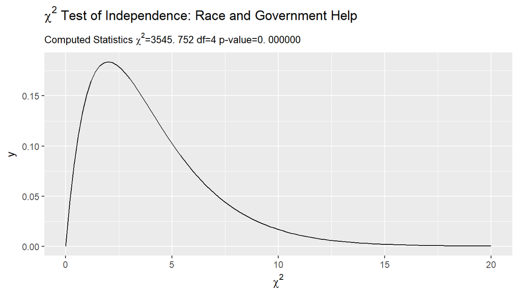

```r
#ID: 4.2

    ggplot(data.frame(x=c(0,20)),aes(x=x))+
         stat_function(fun=dchisq,args=list(df=`df`)) +
        xlab(TeX('$\\chi^2')) +
        ggtitle(TeX(sprintf('$\\chi^2$ Test of Independence: Race and Government Help'))
                ,subtitle =TeX(sprintf('Computed Statistics $\\chi^2$=%.3f df=%d  p-value=%f'
                                       ,chisq_value,df,p_value))
        )
```

### 4.3 Conclusions

The computed statistics from 4.1 and 4.2 are the $\chi^2=$ 3545.7524192 with 4 degrees of freedom. The 4.1 code block computed $\chi^2$ values for quantiles 90, 95, 97.5, 98, 99 as 7.7794403, 9.487729, 11.1432868, 11.6678434, 13.2767041 respectively.

The null hypothesis, $H_0$, assumes that there is no association between races view of the government’s responsibility to help blacks. The p-value 0 is highly significant and literally off the chart. $H_0$ is rejected in favor of the alternative hypothesis, $H_A$, the races view of the government’s responsibility to help blacks differently.

The $\chi^2$ test for independence is performing an overall fit of the observed data and a mathematically computed expected value. No confidence level is computed in this case.

This is not really a surprising result. Over the last 50 years race relationships have improved. I often hear some say that they never thought that they would see a black president in their lifetime. That swing apparently is too much for some and we see the ‘Make America Great Again’ slogan bantered about. That presumes that America is not Great today and was better off in the past. The question, ‘great for who back when and why?’ is never asked.

The first step in resolving racial tensions, any tensions really, starts with a new understanding and reminds me of the idiom,

```
Before you judge a man, walk a mile in his shoes.
```

To get people to think outside of the box, I often ask the question, ‘What is the one thing a fish will never think of?’ Answer - Fire.

### 5.0 Future Research Question and Development

1. Wrangle the data into a 2x2 and perform a two-proportion test to see how the two methods compare. A confidence interval test can be performed two-proportion test.
2. Capstone Project:

   Create a package to process datasets similar to the `gss` dataset.
   - Generate metadata from the Codebook

     > List of variables and their descriptions – See appendix for first stab at this. I can see the descriptions being used to better document descriptions and graphics. Join this to the variable data type either from the Codebook or the str(dataset)
   - A set of standard functions for use in Rmd documents to compute the statistics and graphics.
   - Search the dataset for interesting relationships for further study.

### 5.0 Refactoring of Code from Current project

```r
rc_totals   <- function(cells) {
    cells_with_totals <- cells
    cells_with_totals <- rbind(cells_with_totals,Total=apply(cells_with_totals,2,sum)) # add column totals
    cells_with_totals <- cbind(cells_with_totals,Total=apply(cells_with_totals,1,sum)) # add column totals
    return(cells_with_totals)
}
chisq_calcs <- function(two_way_tbl_matrix) {

    # observed values
    obs_cells     <- two_way_tbl_matrix
    obs_cell_tots <- rc_totals(obs_cells) # add column and row totals

    #
    # compute expected cell values from observed cell values
    #
    row_totals <- apply(two_way_tbl_matrix,1,sum)
    col_totals <- apply(two_way_tbl_matrix,2,sum)
    grand_total  <- sum(row_totals)

    for (c in 1:length(col_totals))
    {
        if (c == 1) {
            exp_cells <- cbind(col_totals[c] * row_totals/grand_total)
        } else {
            exp_cells <- cbind(exp_cells,col_totals[c] * row_totals/grand_total)
        }
    }
    colnames(exp_cells)     <- colnames(obs_cells)                  # Label the cells
    exp_cell_tots           <- rc_totals(exp_cells)                 # add column and row totals
    colnames(exp_cell_tots) <- paste(colnames(exp_cell_tots),'-ex') # Update the labels


    # chisq values
    chisq_cells     <- (obs_cells - exp_cells)^2/exp_cells
    chisq_stat      <- sum(chisq_cells)                                            # chisq statistic
    df              <- (nrow(obs_cells) - 1) * (ncol(obs_cells) - 1)
    chisq_stat_df   <- pchisq(chisq_stat,df,lower.tail = FALSE)
    rv1             <- paste0('chisq_stat=',chisq_stat,' df=',df
                             ,'\npchisq(',chisq_stat,',',df,',lower.tail=FALSE)='
                             , chisq_stat_df
                             )
    chisq_cell_tots <- rc_totals(chisq_cells)
    colnames(chisq_cell_tots) <- paste0(colnames(chisq_cell_tots),'-chisq')

    chisq_tbls <-cbind(obs_cell_tots,exp_cell_tots,chisq_cell_tots)
    rv_list <- list(rv1,chisq_tbls)
    return(rv_list)
}
```

Check functions against exercise results.

```r
m <- matrix(
    c(1159, 6614,   7953
     ,1345, 1357,   332
     ,184,  569,    371)
    ,nrow = 3, ncol = 3, byrow = TRUE
    ,dimnames = list(c('White','Black','Other')
                    ,c('Govt Help Blks','Agree With Both','No Special Treatment')
                    )
)
x <- chisq_calcs(m)
kable(x, caption='5.1 Observed, Expected and Chisq Matrices')
```

5.1 Observed, Expected and Chisq Matrices

| x |
| --- |
| chisq_stat=3545.75241920378 df=4 |
| pchisq(3545.75241920378,4,lower.tail=FALSE)=0 |

|  | Govt Help Blks | Agree With Both | No Special Treatment | Total | Govt Help Blks -ex | Agree With Both -ex | No Special Treatment -ex | Total -ex | Govt Help Blks-chisq | Agree With Both-chisq | No Special Treatment-chisq | Total-chisq |
| --- | --- | --- | --- | --- | --- | --- | --- | --- | --- | --- | --- | --- |
| White | 1159 | 6614 | 7953 | 15726 | 2125.9046 | 6754.1762 | 6845.9191 | 15726 | 439.767888 | 2.909218 | 179.03046 | 621.70757 |
| Black | 1345 | 1357 | 332 | 3034 | 410.1485 | 1303.0758 | 1320.7757 | 3034 | 2130.807458 | 2.231501 | 740.22969 | 2873.26865 |
| Other | 184 | 569 | 371 | 1124 | 151.9469 | 482.7479 | 489.3052 | 1124 | 6.761584 | 15.410564 | 28.60406 | 50.77621 |
| Total | 2688 | 8540 | 8656 | 19884 | 2688.0000 | 8540.0000 | 8656.0000 | 19884 | 2577.336930 | 20.551284 | 947.86420 | 3545.75242 |

**TEST PRINTING OF CODEBLOCK VARIABLES IN RMD BODY**

What is in x[1]:chisq_stat=3545.75241920378 df=4 pchisq(3545.75241920378,4,lower.tail=FALSE)=0

|  | Govt Help Blks | Agree With Both | No Special Treatment | Total | Govt Help Blks -ex | Agree With Both -ex | No Special Treatment -ex | Total -ex | Govt Help Blks-chisq | Agree With Both-chisq | No Special Treatment-chisq | Total-chisq |
| --- | --- | --- | --- | --- | --- | --- | --- | --- | --- | --- | --- | --- |
| White | 1159 | 6614 | 7953 | 15726 | 2125.9046 | 6754.1762 | 6845.9191 | 15726 | 439.767888 | 2.909218 | 179.03046 | 621.70757 |
| Black | 1345 | 1357 | 332 | 3034 | 410.1485 | 1303.0758 | 1320.7757 | 3034 | 2130.807458 | 2.231501 | 740.22969 | 2873.26865 |
| Other | 184 | 569 | 371 | 1124 | 151.9469 | 482.7479 | 489.3052 | 1124 | 6.761584 | 15.410564 | 28.60406 | 50.77621 |
| Total | 2688 | 8540 | 8656 | 19884 | 2688.0000 | 8540.0000 | 8656.0000 | 19884 | 2577.336930 | 20.551284 | 947.86420 | 3545.75242 |

**END OF TEST**

Test on a different dataset:Conservative and Liberals: Political View – Homosexuality

```r
hs<-gss %>% filter(!is.na(homosex) & homosex != 'Other' & !is.na(polviews) & (year == 1974 | year == 2012) ) %>%
    mutate(pv=ifelse(grepl('Lib',polviews),'Liberal'
             ,ifelse(grepl('Mod',polviews),'Moderate'
             ,ifelse(grepl('Con',polviews),'Conservative',polviews
           )))
    ,hs=ifelse(grepl('Al',homosex),'Wrong','Not Wrong')
    )%>%
    group_by(year,pv,hs) %>%summarize(n=n())
    hs2 <-dcast(hs,hs ~ pv,fun.aggregate=sum,value.var = 'n')

hs2 <-dcast(hs,hs ~ pv,fun.aggregate=sum,value.var = 'n')
hs2
```

```
##          hs Conservative Liberal Moderate
## 1 Not Wrong           41      77       74
## 2     Wrong          738     667      878
```

```r
m <- matrix(
    c(41,   77,     74
     ,738,  667,    878)
    ,nrow = 2, ncol = 3, byrow = TRUE
    ,dimnames = list(c('Not Wrong','Wrong')
                    ,c('Conservative','Liberal','Moderate')
                    )
)
x <- chisq_calcs(m)
kable(x[1], caption='Observed, Expected and Chisq Matrices')
```

Observed, Expected and Chisq Matrices

| x |
| --- |
| chisq_stat=13.7586217375172 df=2 |
| pchisq(13.7586217375172,2,lower.tail=FALSE)=0.00102885281554679 |

Just conservatives

```r
hs<-gss %>% filter(!is.na(homosex) & homosex != 'Other' & !is.na(polviews) & (year == 1974 | year == 2012) ) %>%
    filter(grepl('Con',polviews)) %>%
    mutate(pv=ifelse(grepl('Sl',polviews),polviews,'Conservative')
          ,hs=ifelse(grepl('Al',homosex),'Wrong','Not Wrong')
          )%>%
    group_by(pv,hs) %>% summarize(n=n())
    hs2 <-dcast(hs,hs ~ pv,fun.aggregate=sum,value.var = 'n')

hs2 <-dcast(hs,hs ~ pv,fun.aggregate=sum,value.var = 'n')
hs2
```

```
##          hs   5 Conservative
## 1 Not Wrong  21           20
## 2     Wrong 342          396
```

```r
m <- matrix(
    c(21,   20
     ,342,  396)
    ,nrow = 2, ncol = 2, byrow = TRUE
    ,dimnames = list(c('Not Wrong','Wrong')
                    ,c('Slightly Conservative','Conservative')
                    )
)
x<-chisq_calcs(m)
kable(x[2],caption=x[1])
```

chisq_stat=0.37142403051494 df=1 pchisq(0.37142403051494,1,lower.tail=FALSE)=0.542229070933809

|  | Slightly Conservative | Conservative | Total | Slightly Conservative -ex | Conservative -ex | Total -ex | Slightly Conservative-chisq | Conservative-chisq | Total-chisq |
| --- | --- | --- | --- | --- | --- | --- | --- | --- | --- |
| Not Wrong | 21 | 20 | 41 | 19.10526 | 21.89474 | 41 | 0.1879078 | 0.1639676 | 0.3518754 |
| Wrong | 342 | 396 | 738 | 343.89474 | 394.10526 | 738 | 0.0104393 | 0.0091093 | 0.0195486 |
| Total | 363 | 416 | 779 | 363.00000 | 416.00000 | 779 | 0.1983471 | 0.1730769 | 0.3714240 |

```r
hs<-gss %>% filter(!is.na(homosex) & homosex != 'Other' & !is.na(polviews) & (year == 1974 | year == 2012) ) %>%
    filter(grepl('Lib',polviews)) %>%
    mutate(hs=ifelse(grepl('Al',homosex),'Wrong','Not Wrong')
           )%>%
    group_by(polviews,hs) %>% summarize(n=n())
    hs2 <-dcast(hs,hs ~ polviews,fun.aggregate=sum,value.var = 'n')

hs2 <-dcast(hs,hs ~ polviews,fun.aggregate=sum,value.var = 'n')
hs2
```

```
##          hs Extremely Liberal Liberal Slightly Liberal
## 1 Not Wrong                 7      22               48
## 2     Wrong                68     321              278
```

```r
m <- matrix(
    c(7,   22,    48
     ,68,   321,  278)
    ,nrow = 2, ncol = 3, byrow = TRUE
    ,dimnames = list(c('Not Wrong','Wrong')
                    ,c('Extremely', 'Liberal','Slightly')
                    )
)
x<-chisq_calcs(m)
kable(x[2],caption=x[1])
```

chisq_stat=12.5325177473999 df=2 pchisq(12.5325177473999,2,lower.tail=FALSE)=0.00189932090769706

|  | Extremely | Liberal | Slightly | Total | Extremely -ex | Liberal -ex | Slightly -ex | Total -ex | Extremely-chisq | Liberal-chisq | Slightly-chisq | Total-chisq |
| --- | --- | --- | --- | --- | --- | --- | --- | --- | --- | --- | --- | --- |
| Not Wrong | 7 | 22 | 48 | 77 | 7.762097 | 35.49866 | 33.73925 | 77 | 0.0748240 | 5.1329749 | 6.027671 | 11.235470 |
| Wrong | 68 | 321 | 278 | 667 | 67.237903 | 307.50134 | 292.26075 | 667 | 0.0086379 | 0.5925623 | 0.695848 | 1.297048 |
| Total | 75 | 343 | 326 | 744 | 75.000000 | 343.00000 | 326.00000 | 744 | 0.0834619 | 5.7255373 | 6.723519 | 12.532518 |

## Appendix

### GSS variable summary

| Section | Subsection | Col# | Column Name | Description |
| --- | --- | --- | --- | --- |
| 2 Case Identification and Year |  | 1 | caseid | case identification number |
| 2 Case Identification and Year |  | 2 | year | GSS year for this respondent |
| 2 Respondent Background Variables |  | 3 | age | Age of respondent |
| 2 Respondent Background Variables |  | 4 | sex | Respondent’s sex |
| 2 Respondent Background Variables |  | 5 | race | Race of respondent |
| 2 Respondent Background Variables |  | 6 | hispanic | Hispanic specified |
| 2 Respondent Background Variables |  | 7 | uscitzn | Is R US citizen |
| 2 Respondent Background Variables |  | 8 | educ | Highest year of school completed |
| 2 Respondent Background Variables |  | 9 | paeduc | Highest year of school completed, father |
| 2 Respondent Background Variables |  | 10 | maeduc | Highest year of school completed, mother |
| 2 Respondent Background Variables |  | 11 | speduc | Highest year of school completed, spouse |
| 2 Respondent Background Variables |  | 12 | degree | RS highest degree |
| 2 Respondent Background Variables |  | 13 | vetyears | Years in armed forces |
| 2 Respondent Background Variables |  | 14 | sei | Socioeconomic index |
| 2 Personal and Family Information |  | 15 | wrkstat | Labor force status |
| 2 Personal and Family Information |  | 16 | wrkslf | R self-emplyed or works for somebody |
| 2 Personal and Family Information |  | 17 | marital | Marital status |
| 2 Personal and Family Information |  | 18 | spwrksta | Spouse labor force status |
| 2 Personal and Family Information |  | 19 | sibs | Number of brothers and sisters |
| 2 Personal and Family Information |  | 20 | child | Number of children |
| 2 Personal and Family Information |  | 21 | agekdbrn | RS age when 1st child born |
| 2 Personal and Family Information |  | 22 | incom16 | Rs family income when 16 years old |
| 2 Personal and Family Information |  | 23 | born | Was R born in this country |
| 2 Personal and Family Information |  | 24 | parborn | Were RS parents born in this country |
| 2 Personal and Family Information |  | 25 | granborn | How many grandparents born outside US |
| 2 Personal and Family Information |  | 26 | income06 | Total family income |
| 2 Personal and Family Information |  | 27 | coninc | Total family income in constant dollars |
| 2 Personal and Family Information |  | 28 | region | Region of interview |
| 2 Personal and Family Information |  | 29 | partyid | Political party affiliation |
| 2 Personal and Family Information |  | 30 | polviews | Think of self as liberal or conservative |

[output cut: 84 more lines]